# 1 knitr Parameters

## 1.1 Root

```r
knitr::opts_knit$set(root.dir='..')
```

The root directory of the `.rmd` file you want to knit is set to the directory where the `.rmd` file is located by default. In the case above, I changed it to the **directory that is parent to the default directory**. This is useful if you build websites with [R Markdown Websites](https://rmarkdown.rstudio.com/rmarkdown_websites.htm), since **R Markdown Websites** doesn’t allow hierarchical website structure. By changing the root directory, you can more easly organize your project directory structure without violating the requirement of **R Markdown Websites**. This is especially true when you source a lot of Rscripts in the `.Rmd` files.

## 1.2 Code Chunk & Figure Options

```r
library(svglite)
knitr::opts_chunk$set(
    echo = FALSE, # No display code chunks
    message = FALSE,
    warning = FALSE,
    dev='svg', # or 'svglite' for multibite characters
    comment="",
    fig.dim = c(3.5, 3.5)  # (width, height)
)
options(digits = 2) # auto round to 2 decimals when printed
```

# 2 Child Documents

It is possible to write R Markdown in separated files and combine them together before knitting to the output file. See [knitr documentation](https://yihui.name/knitr/) for more info.

## 2.1 Usage

`main.Rmd`:

````
---
title: "This is Title"
author: "Yongfu Liao"
output: html_document
---

```{r setup}
options(knitr.duplicate.label = 'allow')
```

```{r child="part1.Rmd"}
```

```{r child="part2.Rmd"}
```
````

The skeleton file that combines several R Markdown files. Only this file is rendered, other R Markdown files will automatically be inserted in the knitting process.

To avoid code chunks having the same labels, set the option below in `setup` code chunk of `main.Rmd`.

```r
options(knitr.duplicate.label = 'allow')
```

# 3 Conditional Compilation

```r
if (knitr::is_html_output()) {
  ...
}

if (knitr::opts_knit$get('rmarkdown.pandoc.to') == "latex") {
  ...
}
```

# 4 Dynamic Variables

Include **R Code Chunk Variables** in the body of text. This can be a really useful feature for writing thesis or research paper:

- No need to copy & paste the outcomes, such as the statistics. This greatly reduce the risk of error, and it also largely boosts efficiency.
- Automatically updates the results in the paper when the data are updated. This also boosts efficiency and, more importantly, increases the **reproducibility** of the research: you can be confident that the results come directly from the data (unless there are errors in the *code*, which can be ‘seen’, whereas **errors from copy-&-paste’s are invisible**).

Below is a simple demonstration of this feature.

```r
tr1 <- rnorm(n=25, mean=1.1) #data of treatment1
tr2 <- rnorm(n=25, mean=0.9) #data of treatment2
ttest <- t.test(tr1, tr2, paired = T)
diff <- ttest[["estimate"]][["mean of the differences"]]
p_val <- ttest[["p.value"]]
```

1. The mean difference between the two groups is -0.066.

   ```latex
   The mean difference between the two treatments is `r round(diff, 3)`.
   ```

2. The *p*-value of the paired t-test is 0.7767, which is not significant.

   ```latex
       The *p*-value of the paired t-test is `r round(p_val, 4)`, which is `r ifelse(p_val<=0.05, "", "not")` significant.
   ```

# 5 Escaping knitr Special Characters

We may sometimes encounter a situation in which we want to show snippets of R Markdown that have special meaning verbatimly, such as ``r fun()`` or R code chunks.

## 5.1 Display Inline R Code Chunks Verbatimly

Instead of wrapping the code chunk directly with “`` ` ``”, use “`&#96;`” instead:

Use

`<code>&#96;r knitr::combine_words(names(iris))&#96;</code>`

to show

`` `r knitr::combine_words(names(iris))` ``

## 5.2 Display knitr Code Chunks Verbatimly

knitr code chunks (with forms like `` ```{r} ``) will be executed when knitting the Rmd file. In order to show knitr code chunks verbatimly, one has to **suppress** the execution of the code chunks by **adding `` `r ''` `` in front of** `` ```{r} `` and then wrap the whole chunk with **four backticks**:

`````
````Rmd
`r ''````{r}
Some R Code
```
````
`````

The code `` `r ''` `` is for suppressing the execution of the r code chunk after it.

# 6 Bibliographies & Citations

You can read the full documentation of [Bibliographies & Citations](https://rmarkdown.rstudio.com/authoring_bibliographies_and_citations.html) at Rstudio.

## 6.1 Citation syntax

### Classical Citation: **Author**, **year**, and **brackets**

- `Some text [@citekey].`
  - Some text [@RN9].

### In-text Citation: **Author (year)**

- `@citekey Some text`
  - @RN15 Some text
- `@citekey [p. 20] Some text.`
  - @RN9 [p. 20] Some text.

### Year only: Suppress Author

- `Some text [-@citekey].`
  - Some text [-@RN9]

### Two Citations

- `Some text [@citekey1; @citekey2].`
  - Some text [@RN9; @RN15].
- Prefix & Suffix
  - `Text [see @citekey1 pp.45; also, @citekey2 ch. 2].`
  - Text [see @RN9 pp. 45; also, @RN15 ch. 2].

## 6.2 Include `.bib` file in Reference

Rmarkdown requires specific formats of bibliographies. One of the most common one is `.bib`. A lot of people (including me) use Endnote to manage bibliographies. Read [this](https://libguides.usask.ca/c.php?g=218034&p=1458583) to see how to generate `.bib` files from EndNote.

However, you can’t control the format of the **citation key** generated by Endnote. Having a well-structured format of citation key greatly enhance efficiency, which can be done by using **[Zotero](https://www.zotero.org/)** and its extension **[Better BibTeX](https://retorque.re/zotero-better-bibtex/)**. I strongly recommend using this approach, since the learning curve isn’t steep and it only hurts once. The payoff is a long-term efficiency boost.

Below are some syntax in Rmarkdown to control the display of reference in the document.

### Reference heading

The body of cited reference in the `.bib` file will be shown under the header named Reference (it doesn’t matter which **level** of heading you use).

```markdown
## Reference
```

### Specific Refs

Include specific references that were **not cited** in the body of text.

```
---
nocite: |
  @item1, @item2
...
```

### All Refs

Include **All references** in the body of text.

```
---
nocite: |
  @*
...
```

# 7 Emphasis

## An Example

````markdown
```{block2, type="success"}
| This is line 1, pragraph one. [**Red text**]{.red}. Text text text text.
| This is [line 2]{style="color:rgba(255, 0, 0, 1)"} of paragraph one.

Paragraph two starts here.
```
````

This is line 1, pragraph one. **Red text**. Text text text text.  
This is line 2 of paragraph one.

Paragraph two starts here.

## Colored divs

### Bootstrap Alert

You can use bootstrap’s default alert divs in Rmarkdown, defined with four classes:

1. alert alert-success
2. alert alert-warning
3. alert alert-info
4. alert alert-danger

````markdown
```{block, type="alert alert-success"}
Bootstrap-defined colored region
```
````

Bootstrap-defined colored region

### Customized divs

Alternative, you can define your own styled divs, as in my stylesheet[^1]:

There are 4 choices of classes,

1. success
2. warning
3. info
4. error

````markdown
```{block, type="info"}
some text in the colored region
```
````

some text in the colored region

## Bootstrap Callouts

Althougt it’s “Bootstrap” callouts, it’s not contained in default bootstrap theme. I defined it in my stylesheet.

There are 4 choices of classes,

1. bs-callout bs-callout-success
2. bs-callout bs-callout-warning
3. bs-callout bs-callout-info
4. bs-callout bs-callout-error

````markdown
```{block2, type="bs-callout bs-callout-warning"}
### Heading in Callout
**Calleout Text** texttexttexttexttexttext
```
````

### Heading in Callout

**Calleout Text** texttexttexttexttexttext

## New Line

```markdown
| Text of line 1
| Text of line 2

New paragraph
```

Text of line 1  
Text of line 2

New paragraph

## Attach Attributes

By using `[`text`]`, pandoc turns the text in the square brackets into the HTML `<span>` tag. HTML `class`, `id`, attributes specific to `<span>` can then be attached by using the curly braces.

### `class`

Rmarkdown syntax allows attaching attributes (such as class, id, etc.) to certain elements by wrapping attributes into `{ ... }`.

Elements allowed attributes to be attach (by markdown syntax directly):

1. Section: Attributes are added next to **any level of heading**.
2. Link: `[Text](LINK){attributes}`
3. `span`: Text wrapped in `[`, `]`. e.g `[Text with class "red"]{.red}`.

```markdown
[**Red Bold text**]{.red}
```

**Red Bold text**

Note[^2].

### Other Attributes

```markdown
Add color through [span style]{style="color:rgba(255, 0, 0, 1)"}
```

Add color through span style

# 8 Footnotes with Paragraphs

Check [Pandoc](http://pandoc.org/MANUAL.html#footnotes) for details.

```markdown
[^longnote]: Here's one with multiple blocks.

    Subsequent paragraphs are indented to show that they belong to the previous footnote. (JUST IGNORE ME, I AM Exteeeeeendiiiiiiing the text to show the effect of paragraph).

    In this way, multi-paragraph footnotes work like multi-paragraph list items.
```

- Read the output by clicking the superscript[^3].

# 9 Shaped Images (HTML)

## Rounded Edge

```markdown
![](../../local_depend/icons/libreoffice.ico){width=auto height="30%" .rounded}
```

[figure not shown]

### Boostrap

```markdown
![](../../local_depend/icons/libreoffice.ico){width=auto height="30%" .img-rounded}
```

[figure not shown]

Bootstrap Rounded

## Circle Image

```markdown
![](../../local_depend/icons/libreoffice.ico){width=auto height="30%" .circle}
```

[figure not shown]

This is figure Caption

### Boostrap

```markdown
![](../../local_depend/icons/libreoffice.ico){width=auto height="30%" .img-circle}
```

[figure not shown]

Bootstrap Circle

## Thumbnail

```markdown
![](../../local_depend/icons/libreoffice.ico){width=auto height="30%" .img-thumbnail}
```

[figure not shown]

Bootstrap Thumbnail

# 10 Figures

## 10.1 Captions

Include `fig.cap='An Caption of the Plot'` in the code chunk option gives:

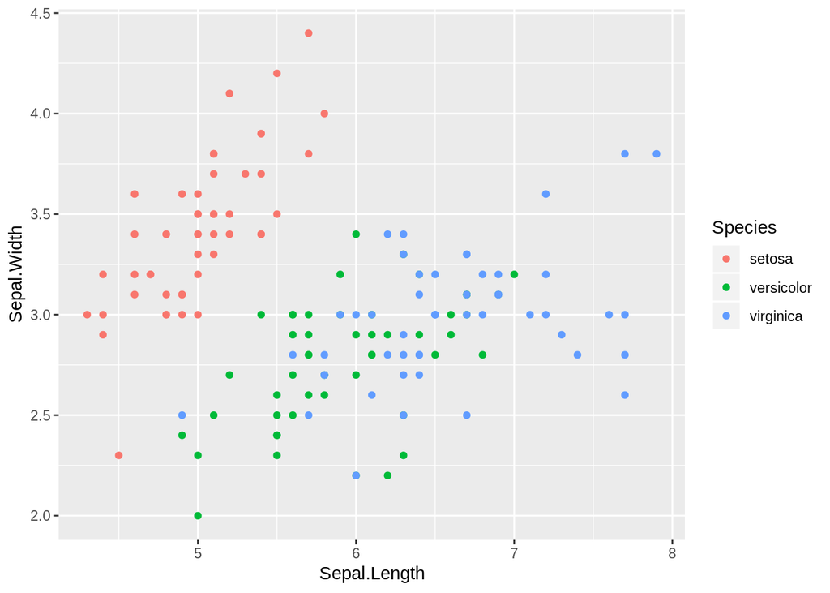

Figure 10.1: An Caption of the Plot

````r
```{r fig.cap='An Caption of the Plot'}
library(ggplot2)
ggplot(iris) +
    geom_point(aes(x = Sepal.Length,
                   y = Sepal.Width,
                   color = Species)
               )
```
````

[^1]: Look at my [stylesheet](https://github.com/liao961120/local_depend/blob/master/style_sheets/style.css) for syntax details.
[^2]: `.red` is also a self-defined class in my stylesheet.
[^3]: Here’s one with multiple blocks.

    Subsequent paragraphs are indented to show that they belong to the previous footnote. (JUST IGNORE ME, I AM Exteeeeeendiiiiiiing the text to show the effect of paragraph).

    In this way, multi-paragraph footnotes work like multi-paragraph list items.